# We R Who We R

Defne Turcan, Deniz Yakici, Mete Alper Yegengil, Beren Cay

2025-03-28

# Introduction

In this project, our first aim was to define the difference between multinomial logistic regression and simple logistic regression. We worked on the dataset “Hitters” by first gathering information about the dataset’s structure, cleaning the missing values, and overall pre-processing it. Then, we created 4 different salary level categories **(RookieBudget, SolidStarter, BeenThereDoneThat, TooRitchToPitch)**. Based on our salary levels, we set the cutoffs with relevant quartiles. With our new salary levels, to gain more information regarding the variables and their relationship with our dependent variable’s levels, we concluded an Exploratory Data Analysis using boxplots. We interpreted the results from our analysis, and determined which variables had the strongest predictive relationship and reported them. We selected the most significant variables and ran our model. While running our model, as we were required to do so, we selected one group member who had the closest birthday to 21 August, and seeded it accordingly. Our model generated LOOCV as a first method for cross-validation. Therefore, we performed LOOCV, and later we determined our error measure. In relation with our dataset, variables, model choices, we chose accuracy as an error measurement. Since we were a group of 4, we performed a second cross-validation. We wanted to continue with the closest birthday method, and selected the second group member who was closest to 21 August. In accordance with the second birthday, our model generated another cross-validation method, being 5-Fold. Lastly, we reduced the model, and tried to create a better model that is performing better than our full model. Then, we concluded both cross-validation methods again to check if our test error has decreased.

## ChatGPT Usage

As a side note, we could have used ChatGPT, but only if we justified it. In this project we have used ChatGPT, first, in handling errors. One of the problems that occured was, while we were knitting the HTML output, it was showing R Studio’s update version notification in every library loading command. Therefore, we asked ChatGPT how to fix it, it gave us **“{r, message=FALSE, warning=FALSE}”** line, which helped us to not have the errors or any other notification pop up in the HTML output.

Secondly, we used ChatGPT during our new model creation, while we were trying several different methods to increase the accuracy, it was not going above 61 percent, so we checked which method could have been used to receive the best accuracy. In accordance with our lab sessions, we tried all the methods, however, we wanted to explore if there were other methods that could increase our accuracy. We obtained the best option as backward selection, therefore, we decided to use that. We will be explaining in depth in the last section of our project, but overall as predicted, it actually gave us a better accuracy then before.

Moreover, we used it in the second cross-validation method. As we are 4 people, we had to conduct the second cross validation. We didn’t want it to be chosen by us, but rather using the same structure as before. Therefore, we used the birthday method. However, after setting the seed with the second closest birthday to 21st of August, it still gave us the LOO-CV method. We couldn’t understand why, so we asked ChatGPT what could we do to prevent this. It gave us this line of code **“second_cv_options <- setdiff(cv_methods,”LOOCV”)“**. By this, our code generated a different cross-validation method from LOO-CV.

Lastly, we consulted ChatGPT for the HTML structure visually. For example, for writing words in bold, or making bullet points, and even making the headers. In addition, we used ChatGPT for having a better visual when we knitted. We wanted our comments to have the same gap from left to right, just like a Word document.

Also, we asked ChatGPT to get confirmation on whether if we could have done EDA in an other way, if our justifications were correct, if we could have used other visualization methods other than boxplots, and even whether if our cross validation methods were functioning correctly.

To sum up, we can say that we, in fact, used ChatGPt, however, we used it to make our project structure both visually and structurally better and more cohesive.

# Simple Logistic Regression vs. Multinomial Logistic Regression and Formalization

To formalize the model in a generic way, we can use this formula to see an overview of how multinomial logistic regression works.

$$\log\left( \frac{P(Y = k)}{P(Y = \text{baseline})} \right) = \beta_{0k}
+ \beta_{1k}X_1 + \beta_{2k}X_2 + \dots + \beta_{pk}X_p$$

where $X_1, X_2, \dots, X_p$ represent predictor variables, and $\beta_{0k}, \beta_{1k}, \dots, \beta_{pk}$ are the coefficients associated with each predictor for category $k$.

In comparison, simple logistic regression models the probability of a binary outcome with two classes and has the following form:

$$\log\left( \frac{P(Y = 1)}{P(Y = 0)} \right) = \beta_0 + \beta_1X_1 +
\beta_2X_2 + \dots + \beta_pX_p$$

So generally, as it is also written in our book ISLR, we studied that a simple logistic regression model uses variables to predict binary outcomes (0/1, yes/no). In general, it can be said that it estimates the probability of one of the two outcomes by using a logistic function. On the other hand, multinomial logistic regression is used when our dependent variable has more than two classes which are not ordered. It estimates the probability of each category in relation to a baseline/reference category.

# Necessary Libraries

We decided to use **tidyverse**, since it is necessary for data manipulation and cleaning which are essential parts for pre-processing. We used the **nnet** library to fit our multinomial logistic regression model. Moreover, as we have been learning in our lab sessions, we used the **ggplot** library to conclude our Exploratory Data Analysis. Then, we used the **caret** library to perform our cross-validation as well as the evaluation of our model’s error measure. Lastly, we used **MASS** library for the creation of our better model, which helped us to use stepAIC() function, which was essential for using backward selection.

```r
library(tidyverse)
library(ggplot2)
library(nnet)
library(caret)
library(MASS)
```

# Pre-processing

In this section, we performed a thorough pre-processing on our dataset, Hitters. We divided our pre-processing into three main sections: understanding the dataset structure, identifying and cleaning missing values,and determining whether to standardize, and removing the outliers are needed. Below, we have written all the necessary functions that we used in pre-processing, and what information we received from them.

**1- Dataset Structure**

- **str():** We used it this function to examine the structure of our dataset. We received an overview of the number of observations (317), the number of variables (20), and the data types of each column.
- **summary():** With this function, We looked at the descriptive statistics for each numeric variable, mainly the minimum, 1st quartile, median, mean, 3rd quartile, and maximum values.
- **dim():** This function helped us confirm that our dataset includes 317 rows and 20 columns. This information gave us a baseline for values before and after cleaning.

**2- Identifying and Addressing the Missing Values**

After understanding the structure of our dataset in the first step, we proceeded with identifying any missing values, and cleaning them.

- **colSums(is.na(Data)):** We identified all the missing values in our dataset. Based on our results, we detected only the Salary column contained exactly 58 missing values (NAs), and all the other variables are complete.
- **na.omit():** As our classification model which is predicting SalaryLevel depends on Salary, the missing values that we found would have stopped us from correctly binning our players into our defined salary levels. Therefore, we used this function to remove all rows that had missing values from salary.
- **cleaned_n <- nrow(Data):** When we removed all the missing values from our dataset, this reduced our total number of 317 observations to 259. To save the remaining rows that are complete, we used this function.

**3- Standardization and Outliers**

Through our analysis of the dataset, and our model, we determined that standardization was not necessary. Since Multinomial Logistic Regression is not a scale-sensitive model, it focuses on log-odds estimation rather than distances. We thought that the model would still efficiently work without the need of scaling. However, we acknowledged that the variables in our dataset, have different ranges from each other, which might affect the interpretability of them.

In our dataset, we did not remove the outliers in the beginning, to see if some variables have outliers that indicate high or low-performing players. For example, there might be a case where a player with an exceptionally high number of hits may appear as an outlier statistically, but, in fact, they are not data errors, they are key influencers in salary determination.

```r
Data <- read.csv("Hitters.csv")
str(Data)
```

```
## 'data.frame':    317 obs. of  20 variables:
##  $ AtBat    : int  293 315 479 496 321 594 185 298 323 574 ...
##  $ Hits     : int  66 81 130 141 87 169 37 73 81 159 ...
##  $ HmRun    : int  1 7 18 20 10 4 1 0 6 21 ...
##  $ Runs     : int  30 24 66 65 39 74 23 24 26 107 ...
##  $ RBI      : int  29 38 72 78 42 51 8 24 32 75 ...
##  $ Walks    : int  14 39 76 37 30 35 21 7 8 59 ...
##  $ Years    : int  1 14 3 11 2 11 2 3 2 10 ...
##  $ CAtBat   : int  293 3449 1624 5628 396 4408 214 509 341 4631 ...
##  $ CHits    : int  66 835 457 1575 101 1133 42 108 86 1300 ...
##  $ CHmRun   : int  1 69 63 225 12 19 1 0 6 90 ...
##  $ CRuns    : int  30 321 224 828 48 501 30 41 32 702 ...
##  $ CRBI     : int  29 414 266 838 46 336 9 37 34 504 ...
##  $ CWalks   : int  14 375 263 354 33 194 24 12 8 488 ...
##  $ League   : chr  "A" "N" "A" "N" ...
##  $ Division : chr  "E" "W" "W" "E" ...
##  $ PutOuts  : int  446 632 880 200 805 282 76 121 143 238 ...
##  $ Assists  : int  33 43 82 11 40 421 127 283 290 445 ...
##  $ Errors   : int  20 10 14 3 4 25 7 9 19 22 ...
##  $ Salary   : num  NA 475 480 500 91.5 ...
##  $ NewLeague: chr  "A" "N" "A" "N" ...
```

```r
summary(Data)
```

```
##      AtBat            Hits           HmRun            Runs
##  Min.   : 16.0   Min.   :  1.0   Min.   : 0.00   Min.   :  0.00
##  1st Qu.:256.0   1st Qu.: 64.0   1st Qu.: 4.00   1st Qu.: 30.00
##  Median :379.0   Median : 96.0   Median : 8.00   Median : 48.00
##  Mean   :381.2   Mean   :101.1   Mean   :10.75   Mean   : 50.89
##  3rd Qu.:512.0   3rd Qu.:137.0   3rd Qu.:16.00   3rd Qu.: 69.00
##  Max.   :687.0   Max.   :238.0   Max.   :40.00   Max.   :130.00
##
##       RBI             Walks            Years            CAtBat
##  Min.   :  0.00   Min.   :  0.00   Min.   : 1.000   Min.   :   19
##  1st Qu.: 28.00   1st Qu.: 22.00   1st Qu.: 4.000   1st Qu.:  822
##  Median : 44.00   Median : 35.00   Median : 6.000   Median : 1928
##  Mean   : 47.95   Mean   : 38.51   Mean   : 7.429   Mean   : 2646
##  3rd Qu.: 63.00   3rd Qu.: 53.00   3rd Qu.:11.000   3rd Qu.: 3919
##  Max.   :121.00   Max.   :105.00   Max.   :24.000   Max.   :14053
##
##      CHits            CHmRun           CRuns             CRBI
##  Min.   :   4.0   Min.   :  0.00   Min.   :   1.0   Min.   :   0.0
##  1st Qu.: 209.0   1st Qu.: 14.00   1st Qu.: 101.0   1st Qu.:  91.0
##  Median : 506.0   Median : 37.00   Median : 247.0   Median : 219.0
##  Mean   : 717.3   Mean   : 68.94   Mean   : 358.1   Mean   : 328.8
##  3rd Qu.:1051.0   3rd Qu.: 90.00   3rd Qu.: 518.0   3rd Qu.: 421.0
##  Max.   :4256.0   Max.   :548.00   Max.   :2165.0   Max.   :1659.0
##
##      CWalks        League            Division            PutOuts
##  Min.   :   0   Length:317         Length:317         Min.   :   0.0
##  1st Qu.:  68   Class :character   Class :character   1st Qu.: 109.0
##  Median : 170   Mode  :character   Mode  :character   Median : 212.0
##  Mean   : 258                                         Mean   : 290.5
##  3rd Qu.: 337                                         3rd Qu.: 325.0
##  Max.   :1566                                         Max.   :1378.0
##
##     Assists          Errors           Salary        NewLeague
##  Min.   :  0.0   Min.   : 0.000   Min.   :  67.5   Length:317
##  1st Qu.:  7.0   1st Qu.: 3.000   1st Qu.: 190.0   Class :character
##  Median : 40.0   Median : 6.000   Median : 420.0   Mode  :character
##  Mean   :107.9   Mean   : 8.091   Mean   : 532.8
##  3rd Qu.:166.0   3rd Qu.:11.000   3rd Qu.: 750.0
##  Max.   :492.0   Max.   :32.000   Max.   :2460.0
##                                   NA's   :58
```

```r
dim(Data)
```

```
## [1] 317  20
```

```r
anyDuplicated(Data)
```

```
## [1] 0
```

```r
colSums(is.na(Data))
```

```
##     AtBat      Hits     HmRun      Runs       RBI     Walks     Years    CAtBat
##         0         0         0         0         0         0         0         0
##     CHits    CHmRun     CRuns      CRBI    CWalks    League  Division   PutOuts
##         0         0         0         0         0         0         0         0
##   Assists    Errors    Salary NewLeague
##         0         0        58         0
```

```r
original_n <- nrow(Data)
Data <- na.omit(Data)
cleaned_n <- nrow(Data)
```

# Defining Categories

After cleaning our data, since Salary as a response variable was quantitative, we focused on making sure that it was a categorical variable. To make it more fun, while we were selecting the quartiles, we gave them creative names. Such as, **RookieBudget**, **SolidStarter**, **BeenThereDoneThat**, and **TooRichToPitch**. Since we divided **SalaryLevel** into 4 categories, we binned it based on the quartiles in 0.25 of percentages. We used the **cut()** function to calculate the cut-off points.

Below, is the cut-off points assigned to each category:

- **“RookieBudget”:** bottom 25%
- **“SolidStarter”:** 25–50%
- **“BeenThereDoneThat”:** 50–75%
- **“TooRichToPitch”:** top 25%

By using **include.lowest = TRUE**, we guaranteed that the lowest value is included in the first bin. Finally, we demonstrated a table for the count of players in each salary level category.

```r
Data$SalaryLevel <- cut(Data$Salary,
                        breaks = quantile(Data$Salary, probs = c(0, 0.25, 0.5, 0.75, 1), na.rm = TRUE),
                        labels = c("RookieBudget", "SolidStarter", "BeenThereDoneThat", "TooRichToPitch"),
                        include.lowest = TRUE)

table(Data$SalaryLevel)
```

```
##
##      RookieBudget      SolidStarter BeenThereDoneThat    TooRichToPitch
##                66                64                70                59
```

# EDA

Through the project we have concluded an exploratory data analysis for almost all variables, but we chose to report the ones that we found which had the strongest relationships with salary levels, while staying consistent with our lab sessions.

Primarily, we decided to use boxplot to visualize the strongest relationships with our salary levels. One of the reasons why we chose boxplot was due to its effectiveness in summarizing and comparing the distribution of numeric variables across all four salary levels. It allowed us to gain important statistical features in a single visual such as the median, interquartile range, and outliers.

Our other purpose of choosing boxplot was because, compared to histograms or scatterplots, it was more efficient in a classification problem like ours where we had a dependent variable which is categorical, and the independent variables being numerical.In addition, we were able to interpret how spread and variance changed across our salary levels.

By using boxplots, we were also able to analyze whether higher salary levels are aligned with stronger performances, which helped us understanding the variables that are the most predictive during our modeling.

## Boxplot 1: Hits Across Salary Levels

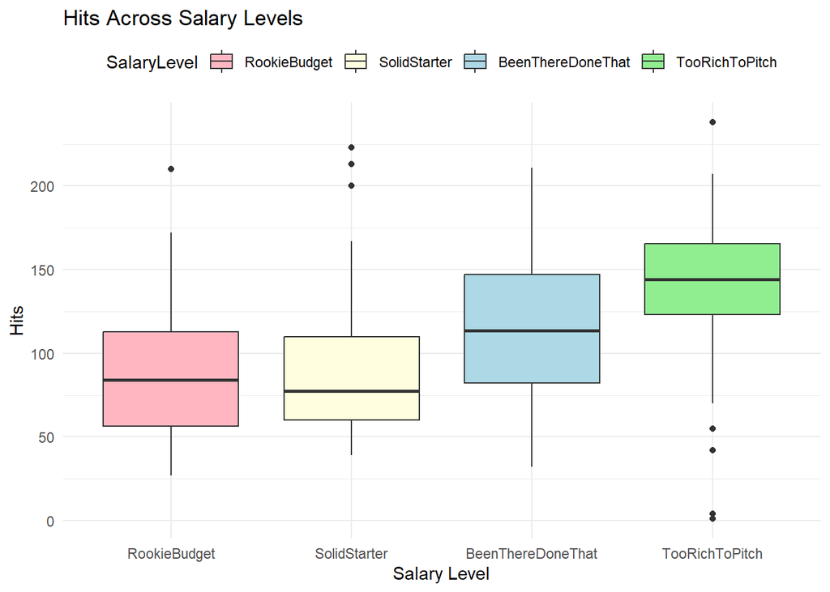

```r
ggplot(Data, aes(x = SalaryLevel, y = Hits, fill = SalaryLevel)) +
  geom_boxplot() +
  scale_fill_manual(values = c(
    "RookieBudget" = "lightpink",
    "SolidStarter" = "lightyellow",
    "BeenThereDoneThat" = "lightblue",
    "TooRichToPitch" = "lightgreen"
  )) +
  labs(
    title = "Hits Across Salary Levels",
    x = "Salary Level",
    y = "Hits"
  ) +
  theme_minimal() +
  theme(legend.position = "top")
```

## Boxplot 2: PutOuts Across Salary Levels

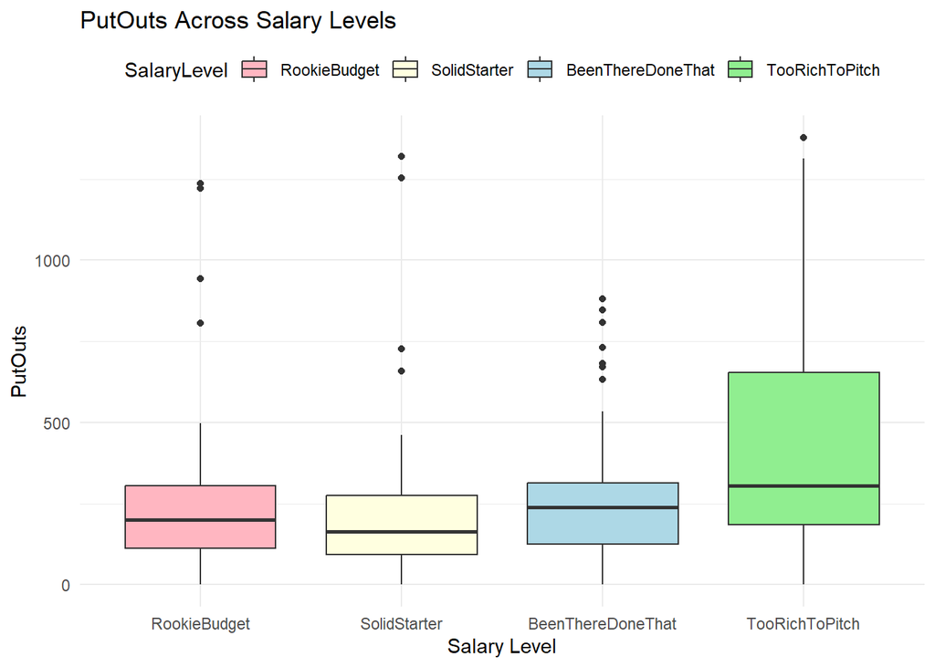

```r
ggplot(Data, aes(x = SalaryLevel, y = PutOuts, fill = SalaryLevel)) +
  geom_boxplot() +
  scale_fill_manual(values = c(
    "RookieBudget" = "lightpink",
    "SolidStarter" = "lightyellow",
    "BeenThereDoneThat" = "lightblue",
    "TooRichToPitch" = "lightgreen"
  )) +
  labs(title = "PutOuts Across Salary Levels", x = "Salary Level", y = "PutOuts") +
  theme_minimal() +
  theme(legend.position = "top")
```

## Boxplot 3: CAtBat Across Salary Levels

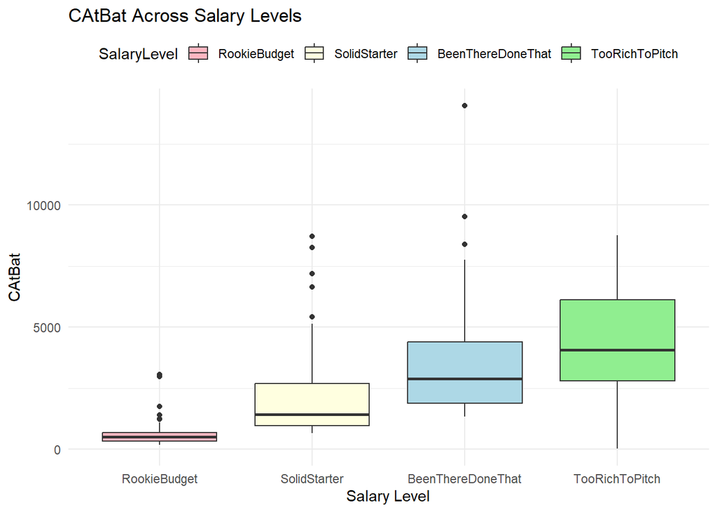

```r
ggplot(Data, aes(x = SalaryLevel, y = CAtBat, fill = SalaryLevel)) +
  geom_boxplot() +
  scale_fill_manual(values = c(
    "RookieBudget" = "lightpink",
    "SolidStarter" = "lightyellow",
    "BeenThereDoneThat" = "lightblue",
    "TooRichToPitch" = "lightgreen"
  )) +
  labs(title = "CAtBat Across Salary Levels", x = "Salary Level", y = "CAtBat") +
  theme_minimal() +
  theme(legend.position = "top")
```

## Boxplot 4: AtBat Across Salary Levels

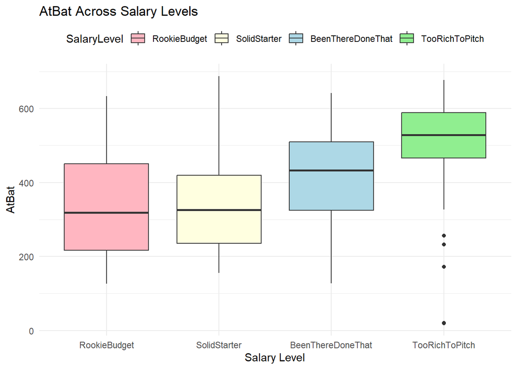

```r
ggplot(Data, aes(x = SalaryLevel, y = AtBat, fill = SalaryLevel)) +
  geom_boxplot() +
  scale_fill_manual(values = c(
    "RookieBudget" = "lightpink",
    "SolidStarter" = "lightyellow",
    "BeenThereDoneThat" = "lightblue",
    "TooRichToPitch" = "lightgreen"
  )) +
  labs(title = "AtBat Across Salary Levels", x = "Salary Level", y = "AtBat") +
  theme_minimal() +
  theme(legend.position = "top")
```

## Boxplot 5: Walks Across Salary Levels

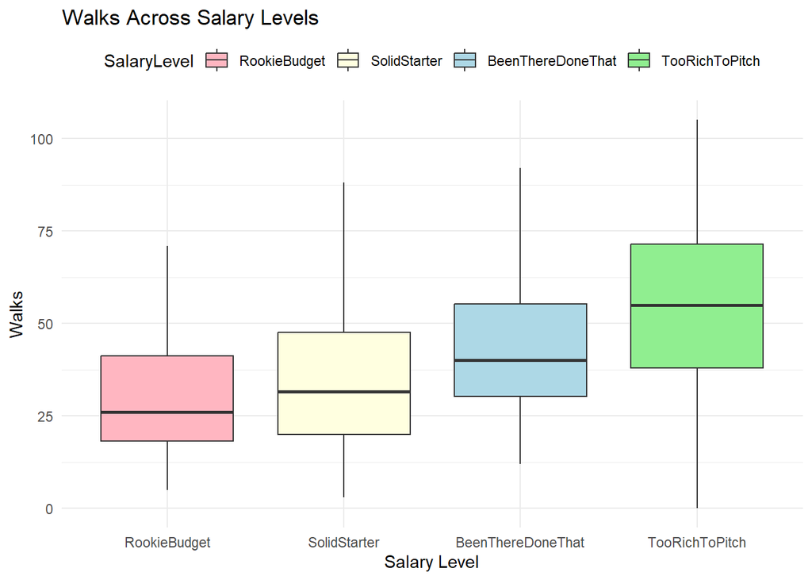

```r
ggplot(Data, aes(x = SalaryLevel, y = Walks, fill = SalaryLevel)) +
  geom_boxplot() +
  scale_fill_manual(values = c(
    "RookieBudget" = "lightpink",
    "SolidStarter" = "lightyellow",
    "BeenThereDoneThat" = "lightblue",
    "TooRichToPitch" = "lightgreen"
  )) +
  labs(title = "Walks Across Salary Levels", x = "Salary Level", y = "Walks") +
  theme_minimal() +
  theme(legend.position = "top")
```

# Running the Model

In order to perform the multinomial logistic regression, we used the **multinom()** function from the **nnet** package, as we have learned in our lab sessions. Main reason why we used **multinom()** as a function, is due to its handling of categorical response variables with more than two outcomes. Since our response variable is **SalaryLevel**, and has 4 different categories, it was an efficient function to run our model.

In our model, we only wanted to include performance metrics. Therefore, we purposefully removed 3 variables from our fitting: League, Division, and New League, which are non-performance metrics, and factors. In other terms, they are categorical indicators of team or league affiliation, not direct measures of a player’s on-field performance. If we had decided to include them, salary differences could have reflected organizational or regional disparities rather than individual success.

During the fitting, we involved all relevant performance-related predictors: both season-based (AtBat, Hits, HmRun, Runs, RBI, Walks, etc.) and career-based statistics (CAtBat, CHits, CHmRun, CRuns, CRBI, CWalks). We also included field-related metrics such as PutOuts, Assists, and Errors. We did not include **Salary** as a predictor in our model because **Salary** was used to create the response variable **SalaryLevel**. If we have included **Salary**, it would have caused a data leakage, where the response variable would “leak” information to the other predictors, which might have caused a biased and an invalid conclusion, also it would have destroyed the purpose of our analysis.

As we previously mentioned, here is our 4 different salary levels: **RookieBudget**, **SolidStarter**, **BeenThereDoneThat**, **TooRichToPitch**. Our model estimated the log-odds of being in each non-baseline category in comparison to the baseline category. In our case, **RookieBudget** was the baseline/reference category. Overall, what our output is an indication of how a one-unit increase in a predictor affects the log-odds of a player in a specific salary level compared to RookieBudget, while all other variables are held constant.

Lastly, in the last lines of our code, you can see that we have chosen **accuracy** as an error measure. Even though we are going to explain it in depth after the cross-validation why we have chosen, briefly, we can say that we chose it because our case is a multinomial classification problem, not just binary. Regarding this, accuracy has a great interpretability which allows us to make comments and comparison on our model. Since **test error = 1 - accuracy**, accuracy directly helps us address minimizing prediction error.

```r
model <- multinom(SalaryLevel ~ AtBat + Hits + HmRun + Runs + RBI + Walks +
                    Years + CAtBat + CHits + CHmRun + CRuns + CRBI + CWalks +
                    PutOuts + Assists + Errors,
                  data = Data)
summary(model)
```

```
## Call:
## multinom(formula = SalaryLevel ~ AtBat + Hits + HmRun + Runs +
##     RBI + Walks + Years + CAtBat + CHits + CHmRun + CRuns + CRBI +
##     CWalks + PutOuts + Assists + Errors, data = Data)
##
## Coefficients:
##                   (Intercept)       AtBat       Hits       HmRun       Runs
## SolidStarter        -2.119442 -0.03593779 0.02194497 -0.14307055 0.15500611
## BeenThereDoneThat   -3.589896 -0.04048693 0.07329386 -0.09775665 0.06661686
## TooRichToPitch      -5.681062 -0.03447630 0.06010758 -0.05073335 0.06707451
##                          RBI        Walks      Years      CAtBat       CHits
## SolidStarter      0.07361810 -0.007672958  0.2314250 0.011938334 -0.02148513
## BeenThereDoneThat 0.05333681  0.044999596  0.1013892 0.009384121 -0.01465302
## TooRichToPitch    0.03888834  0.052997948 -0.1258456 0.008701673 -0.01464651
##                       CHmRun        CRuns         CRBI      CWalks
## SolidStarter      0.03507606 -0.023852861 -0.017924048 0.011663216
## BeenThereDoneThat 0.03284238 -0.011127212 -0.015857585 0.006668275
## TooRichToPitch    0.02077034 -0.005058175 -0.008229895 0.004192038
##                         PutOuts     Assists      Errors
## SolidStarter      -0.0001852251 0.007906414 -0.14984796
## BeenThereDoneThat  0.0004663703 0.007587667 -0.10888977
## TooRichToPitch     0.0017017788 0.006098294 -0.07424669
##
## Std. Errors:
##                   (Intercept)      AtBat       Hits    HmRun       Runs
## SolidStarter      0.006417864 0.01289570 0.04538321 0.118291 0.05791268
## BeenThereDoneThat 0.004682597 0.01318963 0.04637865 0.120964 0.05936727
## TooRichToPitch    0.005952914 0.01350297 0.04777750 0.124539 0.06115663
##                          RBI      Walks      Years      CAtBat      CHits
## SolidStarter      0.04804173 0.03878508 0.07028187 0.005863058 0.02425990
## BeenThereDoneThat 0.04975797 0.03977985 0.06205622 0.005830970 0.02431348
## TooRichToPitch    0.05128045 0.04127905 0.08223463 0.005838920 0.02454698
##                       CHmRun      CRuns       CRBI     CWalks     PutOuts
## SolidStarter      0.05413351 0.02243750 0.02460077 0.01654191 0.001272324
## BeenThereDoneThat 0.05393460 0.02254007 0.02454886 0.01654104 0.001168016
## TooRichToPitch    0.05441433 0.02289911 0.02477038 0.01664024 0.001144123
##                       Assists     Errors
## SolidStarter      0.003832414 0.07304611
## BeenThereDoneThat 0.003876996 0.07404536
## TooRichToPitch    0.004030371 0.07814092
##
## Residual Deviance: 406.1243
## AIC: 508.1243
```

```r
predicted_classes <- predict(model, newdata = Data)
actual_classes <- Data$SalaryLevel
accuracy <- mean(predicted_classes == actual_classes)
paste("Training Accuracy:", round(accuracy * 100, 2), "%")
```

```
## [1] "Training Accuracy: 69.88 %"
```

## In-Depth Interpretation of Our Predictors

### Weak/Inconsistent Predictors

- **Errors:** From the results we have obtained, the coefficients of Errors are negative, which may suggest that players who make more fielding mistakes tend to be categorized within lower salary levels. In addition, the coefficients are small and the standard errors are significantly large, which makes Errors as a predictor, weak.
- **PutOuts & Assists:** For both variables, they have a fluctuating and small coefficients. They have some cases where the standard errors are as large as or larger than their effect sizes. Additionally, since these variables are position-dependent, they add noise to the model. Overall, they have a minimal explanatory value.
- **Career Metrics (CAtBat, CHits, CHmRun, CRuns, CRBI, CWalks):** Variables within the career metrics represent accumulated performance. This total performance may overlap with seasonal performance metrics that are already in the model. They tend to have low coefficient values and large standard errors. Therefore, despite their relevance conceptually, they do not show clear predictive value.

On the other hand, CHits & CHmRun variables have been, sometimes, statistically meaningful. They had small coefficients like the rest of the career metrics, and they were inconsistent. This demonstrated inconsistency, and weak relationship.

## Residual Deviance and AIC

Similar to what we had in linear regression as Residual Sum of Squares, in logistic regression Residual Deviance is a measurement that is used to understand how well the model fits the observed data. Lower the residual deviance, better the model, and the better explanation of the variation in the response variable.

After running our model, we obtained 406.1243 from Residual Deviance. We interpreted as, our model provides a reasonable level of fit to the data. It can be said that, there is still some error in how well our model can predict which salary level each player belongs to. However, we can also say that our model is not random, the deviance is quite moderate, suggesting a statistically meaningful information about our results.

On the other hand, AIC (Akaike Information Criterion), is a measure for finding the right model which fits the data well, also ensuring that the model is not overly complex by penalizing, i.e. our model does not use too many predictors unnecessarily. Therefore, the lower the AIC, better the model fit.

In our results, we obtained an AIC of 508.1243. While we cannot compare to any previous model fittings, we can deduct that our model has been penalized for complexity since the score is not that low, probably due to unnecessary predictors. However, it also indicates that our model is not too much of an overfit.

Overall, even though our model has a large number of predictors, it still has a reasonable performance. In addition, the model fit is not poor, while demonstrating a moderate predictive ability. However, there is a clear room for improvement. Hence, we can say that our model could benefit from reducing less informative predictors and/or tuning, to enhance both its fit and predictive accuracy.

## Training Accuracy

From running our full model, we have received a very optimistic accuracy, **%69.88**. As we know, training accuracy measures how well the model is able to classify the same data it was trained on. In other words, almost 70% of the players were correctly classified into their correct salary levels using the predictors.

We can definitely say that approximately 70% accuracy in a multi-class classification problem with four salary levels is actually pretty reasonable, because random guessing would only give us about 25% accuracy (since 4 categories => 1/4 = 25%). Also, this result indicates that our full model has learned the patterns and is able to perform on the test data with the understanding of important relationships. In addition, our training accuracy also doesn’t show too much overfitting, since it is not too close to 100 percent.

However, we should not be tricked by this since this is the training accuracy, what actually matters is the test error. Therefore, we have to perform cross-validation to gather more information how our model performs on the test set.

# Cross-Validation with LOO-CV

Just like we mentioned above, to understand whether our model is performing well with little test error on the test set, we have to carry out cross-validation. The main reason why we are conducting this is because training accuracy alone is not a reliable measure of how well a model will perform on new, unseen data. Also, by applying cross validation to both the full model and the reduced model, we can fairly compare their performance and choose the model that generalizes better.

As we were given in the project guidelines, we had to make the code generate that selects a random cross validation method out of those 5 that are stated. In the beginning, since our group consists of 4 people, we started by determining the group member who had the closest birthday to the 21st of August.

The group member who had the closest birthday to 21st August was our dearest member: **Deniz Yakici** with her birthday being 05/07/2004. Therefore, we set the seed to her birthday. We selected the method randomly and it picked LOO-CV.

To give a general description, LOO-CV is a type of cross-validation where the model is trained n times (n being the number of observations), and each time the model leaves out only one observation as the test set, and uses the rest as the training set.

```r
cv_methods <- c("Validation Set", "LOOCV", "5-Fold CV", "10-Fold CV")
set.seed(05072004)
selected_method <- sample(cv_methods, 1)
selected_method
```

```
## [1] "LOOCV"
```

## Beginning the LOO-CV Loop

This code chunk begins with initializing an empty vector to store the predicted salary levels for each observation in the dataset. Then, we manually created a for loop to iterate through every row in the dataset.

Within the loop:

**train_data <- Data[-i, ]**

**test_data <- Data[i, ]** is used to split our data into train and test. Our train data, which we used to fit the model, is all the rows except the i-th one. Our test data is only the i-th row, which we used it for testing and prediction, normally so-called “unseen data”.

Then, we trained a multinomial logistic regression, similar to what we have done without a cross-validation. We continued using the same variables, like before.

After the loop, we converted the actual SalaryLevel values to characters for comparison. We built a confusion matrix to also compare predictions to the actual values. By this matrix, we were able to understand how many predictions were correct or misclassified.

Lastly, we calculated the prediction accuracy, as the percentage of correct predictions over the total predictions.

```r
loocv_preds <- c()

for (i in 1:nrow(Data)) {
  train_data <- Data[-i, ]
  test_data <- Data[i, ]
  model <- multinom(SalaryLevel ~ AtBat + Hits + HmRun + Runs + RBI + Walks +
                    Years + CAtBat + CHits + CHmRun + CRuns + CRBI + CWalks +
                    PutOuts + Assists + Errors, data = train_data, trace = FALSE)
  pred <- predict(model, newdata = test_data)
  loocv_preds <- c(loocv_preds, as.character(pred))
}

actual <- as.character(Data$SalaryLevel)
conf_matrix <- table(Predicted = loocv_preds, Actual = actual)
print(conf_matrix)
```

```
##                    Actual
## Predicted           BeenThereDoneThat RookieBudget SolidStarter TooRichToPitch
##   BeenThereDoneThat                28            1           11             23
##   RookieBudget                      2           58           12              2
##   SolidStarter                     22            5           38              3
##   TooRichToPitch                   18            2            3             31
```

```r
accuracy <- mean(loocv_preds == actual)
paste("LOOCV Accuracy:", round(accuracy * 100, 2), "%")
```

```
## [1] "LOOCV Accuracy: 59.85 %"
```

### Interpretation

We read the results of confusion matrix, as diagonal entries being the correct predictions, whereas the off-diagonal ones being the misclassifications.

- **BeenThereDoneThat:** 28 players were correctly classified.
- **RookieBudget:** 58 players were correctly classified.
- **SolidStarter:** 38 players were correctly classified.
- **TooRichToPitch:** 31 players were correctly classified.

Overall, our model reached **% 59.85** of LOO-CV accuracy. From this result, we made the deduction that almost 60 percent of the salary level predictions were actually the same as the true salary level categories. This accuracy can be said to be moderate, and the overall performance is reasonable but not the best to generalize on an unseen data.

# Second Cross-Validation

Within our project, since we are 4 people, we conducted a second cross-validation. Rather than choosing randomly another one ourselves, we decided to be consistent with the first method of choice, but this time we chose the second closest birthday to 21st of August. First, we used the same code structure in LOO-CV to sample the cross-validation method, however, it gave us, again, LOO-CV. Therefore, we used ChatGPT to modify the code to make sure that the CV method was different from the previous one. ChatGPT provided us with this **setdiff(cv_methods, “LOOCV”)** code snippet. Our group member, who had the second closest birthday to 21st of August, was **Defne Turcan** with her birthday being 02/12/2005. Therefore, we set the seed accordingly, and proceeded with the same structure as before.

Our code picked the second cross-validation method: 5-Fold CV.

5-Fold Cross-Validation method is trained and tested 5 times. In each time, 4 folds are used for training, and the remaining 1 is used for testing. The whole process rotates. This ensures that every fold goes through the test set once. After the runs, 5-Fold takes the average all errors from each fold.

```r
second_cv_options <- setdiff(cv_methods, "LOOCV")
set.seed(02122005)
second_method <- sample(second_cv_options, 1)
second_method
```

```
## [1] "5-Fold CV"
```

## Beginning of 5-Fold Loop

With the first line of code, we split the data into 5 groups (folds) while using sampling based on the SalaryLevel. We created an empty vector to store the predicted salary levels, similar to before, from each test fold. We manually initiated a for loop to train and test the model with each fold.

Within the loop:

We wrote a **test_index** which holds the row numbers for the i-th fold. Then split the data into train and test. Our **train_data** contains the other 4 folds which we used to fit the model, whereas the **test_data** is used to evaluate our model performance.

Lastly, we predicted the salary level categories on our unseen test data, and stored the results in appropriate indices of **kfold_preds**. Then, we stored the true class labels with using **actual <- as.character(Data$SalaryLevel)**.

To compare, we used the confusion matrix. It allowed us to compare the predicted values and the actual values. Eventually, we checked how many predictions were actually matching their correct categories.

```r
set.seed(02122005)
folds <- createFolds(Data$SalaryLevel, k = 5, list = TRUE)

kfold_preds <- rep(NA, nrow(Data))

for (i in 1:5) {
  test_index <- folds[[i]]
  train_data <- Data[-test_index, ]
  test_data <- Data[test_index, ]

  model <- multinom(SalaryLevel ~ AtBat + Hits + HmRun + Runs + RBI + Walks +
                      Years + CAtBat + CHits + CHmRun + CRuns + CRBI + CWalks +
                      PutOuts + Assists + Errors,
                    data = train_data, trace = FALSE)

  preds <- predict(model, newdata = test_data)
  kfold_preds[test_index] <- as.character(preds)
}


actual <- as.character(Data$SalaryLevel)
kfold_conf_matrix <- table(Predicted = kfold_preds, Actual = actual)
print(kfold_conf_matrix)
```

```
##                    Actual
## Predicted           BeenThereDoneThat RookieBudget SolidStarter TooRichToPitch
##   BeenThereDoneThat                29            1           11             18
##   RookieBudget                      0           59           11              2
##   SolidStarter                     25            5           37              6
##   TooRichToPitch                   16            1            5             33
```

```r
kfold_accuracy <- mean(kfold_preds == actual)
paste("5-Fold CV Accuracy:", round(kfold_accuracy * 100, 2), "%")
```

```
## [1] "5-Fold CV Accuracy: 61 %"
```

### Interpretation

Same as LOO-CV results, we received the confusion matrix. It gave us the statistics of how many times our model correctly predicted our salary levels, and how many times it misclassified them. To read the matrix, we followed each row being predicted values, and each column being the actual values.

From these results we made the assumption that the model struggles to differentiate between mid-high performers and top performers. Moreover, SolidStarter and BeenThereDoneThat probably have similar seasonal and career statistics, that’s why they overlap and cause misclassification.

Since we obtained an accuracy of 61 %, we made the claim that it has increased in accuracy compared to LOO-CV, but still has a moderate test error. This can be explained by since 5-Fold cross-validation usually provides a more stable and realistic estimate of model performance compared to LOO-CV which tends to have higher variance.

# Better Model

```r
full_model <- multinom(SalaryLevel ~ AtBat + Hits + HmRun + Runs + RBI + Walks +
                         Years + CAtBat + CHits + CHmRun + CRuns + CRBI + CWalks +
                         PutOuts + Assists + Errors, data = Data, trace = FALSE)


reduced_model <- stepAIC(full_model, direction = "backward", trace = TRUE)
```

```
## Start:  AIC=508.12
## SalaryLevel ~ AtBat + Hits + HmRun + Runs + RBI + Walks + Years +
##     CAtBat + CHits + CHmRun + CRuns + CRBI + CWalks + PutOuts +
##     Assists + Errors
##
##           Df    AIC
## - CHmRun   3 503.32
## - CHits    3 503.34
## - CRBI     3 504.33
## - HmRun    3 504.57
## - RBI      3 505.06
## - CWalks   3 505.38
## - Hits     3 506.44
## - CRuns    3 506.73
## - Assists  3 507.01
## - PutOuts  3 507.12
## - Years    3 507.18
## - Errors   3 507.24
## - CAtBat   3 507.38
## <none>       508.12
## - Walks    3 511.00
## - AtBat    3 513.10
## - Runs     3 514.16
##
## Step:  AIC=503.32
## SalaryLevel ~ AtBat + Hits + HmRun + Runs + RBI + Walks + Years +
##     CAtBat + CHits + CRuns + CRBI + CWalks + PutOuts + Assists +
##     Errors
##
##           Df    AIC
## - CRBI     3 498.94
## - HmRun    3 498.95
## - RBI      3 499.63
## - CWalks   3 500.17
## - CHits    3 501.00
## - CRuns    3 501.98
## - Assists  3 501.99
## - Years    3 502.16
## - Hits     3 502.25
## - Errors   3 502.43
```

[output cut: 131 more lines]

```
## - CHits    3 486.56
##
## Step:  AIC=478.46
## SalaryLevel ~ AtBat + Hits + Runs + Walks + CAtBat + CHits +
##     PutOuts
##
##           Df    AIC
## <none>       478.46
## - Runs     3 479.90
## - PutOuts  3 480.02
## - Hits     3 480.15
## - Walks    3 480.52
## - AtBat    3 488.48
## - CHits    3 489.93
## - CAtBat   3 490.00
```

```r
predicted_reduced <- predict(reduced_model, newdata = Data)


accuracy_reduced <- mean(predicted_reduced == Data$SalaryLevel)
paste("Reduced Model Accuracy:", round(accuracy_reduced * 100, 2), "%")
```

```
## [1] "Reduced Model Accuracy: 67.95 %"
```

## Performing Cross-Validations on the Reduced Model

### 5-Fold CV

```r
set.seed(02122005)
folds <- createFolds(Data$SalaryLevel, k = 5, list = TRUE)

kfold_preds <- rep(NA, nrow(Data))

for (i in 1:5) {
  test_index <- folds[[i]]
  train_data <- Data[-test_index, ]
  test_data <- Data[test_index, ]


  model_reduced_cv <- multinom(SalaryLevel ~ AtBat + Hits + Runs + Walks + CAtBat + CHits +
    PutOuts, data = train_data, trace = FALSE)

  preds <- predict(model_reduced_cv, newdata = test_data)
  kfold_preds[test_index] <- as.character(preds)
}


actual <- as.character(Data$SalaryLevel)
conf_matrix <- table(Predicted = kfold_preds, Actual = actual)
print(conf_matrix)
```

```
##                    Actual
## Predicted           BeenThereDoneThat RookieBudget SolidStarter TooRichToPitch
##   BeenThereDoneThat                33            1           11             22
##   RookieBudget                      0           60           12              2
##   SolidStarter                     22            4           37              6
##   TooRichToPitch                   15            1            4             29
```

```r
kfold_accuracy <- mean(kfold_preds == actual)
paste("5-Fold CV Accuracy (Reduced Model):", round(kfold_accuracy * 100, 2), "%")
```

```
## [1] "5-Fold CV Accuracy (Reduced Model): 61.39 %"
```

### LOO-CV

To be even more consistent on calculating the test error. Since we used LOO-CV as a cross-validation method before, we wanted to run it also on the reduced model. We again set the same seed as the full model, and ran it with only using the variables that we had with stepAIC. Impressively, we received a significant increase in accuracy, almost %4. After conducting cross-validatio LOO-CV on our reduced model. We obtained %63.71 as the accuracy. Compared to our previous accuracy in the full model, which was %59.85. We can see a significant increase, suggesting our model being better than before with having lower test error.

```r
set.seed(05072004)
n <- nrow(Data)
loo_preds <- rep(NA, n)

for (i in 1:n) {

  train_data <- Data[-i, ]
  test_data <- Data[i, , drop = FALSE]

  model_reduced_loo <- multinom(SalaryLevel ~ AtBat + Hits + Runs + Walks + CAtBat + CHits +
    PutOuts, data = train_data, trace = FALSE)

  pred <- predict(model_reduced_loo, newdata = test_data)
  loo_preds[i] <- as.character(pred)
}


actual_loo <- as.character(Data$SalaryLevel)
loo_conf_matrix <- table(Predicted = loo_preds, Actual = actual_loo)
print(loo_conf_matrix)
```

```
##                    Actual
## Predicted           BeenThereDoneThat RookieBudget SolidStarter TooRichToPitch
##   BeenThereDoneThat                35            1           10             22
##   RookieBudget                      1           61           13              2
##   SolidStarter                     20            3           37              3
##   TooRichToPitch                   14            1            4             32
```

```r
loo_accuracy <- mean(loo_preds == actual_loo)
paste("LOOCV Accuracy (Reduced Model):", round(loo_accuracy * 100, 2), "%")
```

```
## [1] "LOOCV Accuracy (Reduced Model): 63.71 %"
```

## Interpretation on the Reduced Model

We also looked for other methods to improve our model more, if our function wasn’t mulinom() but a random forest or decision trees we could have performed hyperparameter tuning, but since we don’t have any parameters to tune, this method was for us the best in having lower test error. Despite these, we saw that the reduced model achieved a balance between model complexity and predictive ability, successfully lowering the test error while enhancing model robustness.

# Our Model With Including Factor Variables

Even though this part was not asked from us, to have a more compact and a better understanding of our model we decided to reconsider our approach. Therefore, we decided to complete the entire project again but this time with the factor variables. As we mentioned in the beginning, we purposefully removed 3 variables: League, Division, and NewLeague. However, we realised that what if they are actually significant. Because we understood that sometimes categorical attributes can carry important structural information about a player’s playing context, such as the league type or the division they belong to, which can ultimately influence their salary.

Below you can find the entire coding just with the difference of adding factor variables.

```r
library(tidyverse)
library(ggplot2)
library(nnet)
library(caret)
library(MASS)
```

```r
Data <- read.csv("Hitters.csv")
str(Data)
```

```
## 'data.frame':    317 obs. of  20 variables:
##  $ AtBat    : int  293 315 479 496 321 594 185 298 323 574 ...
##  $ Hits     : int  66 81 130 141 87 169 37 73 81 159 ...
##  $ HmRun    : int  1 7 18 20 10 4 1 0 6 21 ...
##  $ Runs     : int  30 24 66 65 39 74 23 24 26 107 ...
##  $ RBI      : int  29 38 72 78 42 51 8 24 32 75 ...
##  $ Walks    : int  14 39 76 37 30 35 21 7 8 59 ...
##  $ Years    : int  1 14 3 11 2 11 2 3 2 10 ...
##  $ CAtBat   : int  293 3449 1624 5628 396 4408 214 509 341 4631 ...
##  $ CHits    : int  66 835 457 1575 101 1133 42 108 86 1300 ...
##  $ CHmRun   : int  1 69 63 225 12 19 1 0 6 90 ...
##  $ CRuns    : int  30 321 224 828 48 501 30 41 32 702 ...
##  $ CRBI     : int  29 414 266 838 46 336 9 37 34 504 ...
##  $ CWalks   : int  14 375 263 354 33 194 24 12 8 488 ...
##  $ League   : chr  "A" "N" "A" "N" ...
##  $ Division : chr  "E" "W" "W" "E" ...
##  $ PutOuts  : int  446 632 880 200 805 282 76 121 143 238 ...
##  $ Assists  : int  33 43 82 11 40 421 127 283 290 445 ...
##  $ Errors   : int  20 10 14 3 4 25 7 9 19 22 ...
##  $ Salary   : num  NA 475 480 500 91.5 ...
##  $ NewLeague: chr  "A" "N" "A" "N" ...
```

```r
summary(Data)
```

```
##      AtBat            Hits           HmRun            Runs
##  Min.   : 16.0   Min.   :  1.0   Min.   : 0.00   Min.   :  0.00
##  1st Qu.:256.0   1st Qu.: 64.0   1st Qu.: 4.00   1st Qu.: 30.00
##  Median :379.0   Median : 96.0   Median : 8.00   Median : 48.00
##  Mean   :381.2   Mean   :101.1   Mean   :10.75   Mean   : 50.89
##  3rd Qu.:512.0   3rd Qu.:137.0   3rd Qu.:16.00   3rd Qu.: 69.00
##  Max.   :687.0   Max.   :238.0   Max.   :40.00   Max.   :130.00
##
##       RBI             Walks            Years            CAtBat
##  Min.   :  0.00   Min.   :  0.00   Min.   : 1.000   Min.   :   19
##  1st Qu.: 28.00   1st Qu.: 22.00   1st Qu.: 4.000   1st Qu.:  822
##  Median : 44.00   Median : 35.00   Median : 6.000   Median : 1928
##  Mean   : 47.95   Mean   : 38.51   Mean   : 7.429   Mean   : 2646
##  3rd Qu.: 63.00   3rd Qu.: 53.00   3rd Qu.:11.000   3rd Qu.: 3919
##  Max.   :121.00   Max.   :105.00   Max.   :24.000   Max.   :14053
##
##      CHits            CHmRun           CRuns             CRBI
##  Min.   :   4.0   Min.   :  0.00   Min.   :   1.0   Min.   :   0.0
##  1st Qu.: 209.0   1st Qu.: 14.00   1st Qu.: 101.0   1st Qu.:  91.0
##  Median : 506.0   Median : 37.00   Median : 247.0   Median : 219.0
##  Mean   : 717.3   Mean   : 68.94   Mean   : 358.1   Mean   : 328.8
##  3rd Qu.:1051.0   3rd Qu.: 90.00   3rd Qu.: 518.0   3rd Qu.: 421.0
##  Max.   :4256.0   Max.   :548.00   Max.   :2165.0   Max.   :1659.0
##
##      CWalks        League            Division            PutOuts
##  Min.   :   0   Length:317         Length:317         Min.   :   0.0
##  1st Qu.:  68   Class :character   Class :character   1st Qu.: 109.0
##  Median : 170   Mode  :character   Mode  :character   Median : 212.0
##  Mean   : 258                                         Mean   : 290.5
##  3rd Qu.: 337                                         3rd Qu.: 325.0
##  Max.   :1566                                         Max.   :1378.0
##
##     Assists          Errors           Salary        NewLeague
##  Min.   :  0.0   Min.   : 0.000   Min.   :  67.5   Length:317
##  1st Qu.:  7.0   1st Qu.: 3.000   1st Qu.: 190.0   Class :character
##  Median : 40.0   Median : 6.000   Median : 420.0   Mode  :character
##  Mean   :107.9   Mean   : 8.091   Mean   : 532.8
##  3rd Qu.:166.0   3rd Qu.:11.000   3rd Qu.: 750.0
##  Max.   :492.0   Max.   :32.000   Max.   :2460.0
##                                   NA's   :58
```

```r
dim(Data)
```

```
## [1] 317  20
```

```r
anyDuplicated(Data)
```

```
## [1] 0
```

```r
colSums(is.na(Data))
```

```
##     AtBat      Hits     HmRun      Runs       RBI     Walks     Years    CAtBat
##         0         0         0         0         0         0         0         0
##     CHits    CHmRun     CRuns      CRBI    CWalks    League  Division   PutOuts
##         0         0         0         0         0         0         0         0
##   Assists    Errors    Salary NewLeague
##         0         0        58         0
```

```r
original_n <- nrow(Data)
Data <- na.omit(Data)
cleaned_n <- nrow(Data)
```

```r
Data$SalaryLevel <- cut(Data$Salary,
                        breaks = quantile(Data$Salary, probs = c(0, 0.25, 0.5, 0.75, 1), na.rm = TRUE),
                        labels = c("RookieBudget", "SolidStarter", "BeenThereDoneThat", "TooRichToPitch"),
                        include.lowest = TRUE)

table(Data$SalaryLevel)
```

```
##
##      RookieBudget      SolidStarter BeenThereDoneThat    TooRichToPitch
##                66                64                70                59
```

```r
Data$League <- as.factor(Data$League)
Data$Division <- as.factor(Data$Division)
Data$NewLeague <- as.factor(Data$NewLeague)


model <- multinom(SalaryLevel ~ AtBat + Hits + HmRun + Runs + RBI + Walks +
                    Years + CAtBat + CHits + CHmRun + CRuns + CRBI + CWalks +
                    PutOuts + Assists + Errors + Division + League + NewLeague,
                  data = Data)
summary(model)
```

```
## Call:
## multinom(formula = SalaryLevel ~ AtBat + Hits + HmRun + Runs +
##     RBI + Walks + Years + CAtBat + CHits + CHmRun + CRuns + CRBI +
##     CWalks + PutOuts + Assists + Errors + Division + League +
##     NewLeague, data = Data)
##
## Coefficients:
##                   (Intercept)       AtBat       Hits       HmRun       Runs
## SolidStarter        -2.703014 -0.04024208 0.03770561 -0.15087782 0.15694549
## BeenThereDoneThat   -4.476484 -0.04641756 0.09341681 -0.10369610 0.07151012
## TooRichToPitch      -5.566354 -0.03789970 0.07758256 -0.03622496 0.06256441
##                          RBI        Walks      Years     CAtBat       CHits
## SolidStarter      0.08239505 -0.001403527  0.2406987 0.01536027 -0.02884436
## BeenThereDoneThat 0.06304987  0.049998102  0.1300238 0.01294420 -0.02352491
## TooRichToPitch    0.03364088  0.062803887 -0.1895948 0.01259362 -0.02251776
##                       CHmRun       CRuns        CRBI       CWalks       PutOuts
## SolidStarter      0.04594024 -0.03023788 -0.02237094 0.0079807355 -0.0002331066
## BeenThereDoneThat 0.04349788 -0.01571901 -0.02014732 0.0026580249  0.0005111301
## TooRichToPitch    0.03184823 -0.01314544 -0.01203831 0.0002506327  0.0016423656
##                       Assists      Errors  DivisionW  LeagueN NewLeagueN
## SolidStarter      0.008361676 -0.17266354 -0.5155852 3.422584  -3.046514
## BeenThereDoneThat 0.008382301 -0.13961087 -0.3811349 3.458222  -2.631971
## TooRichToPitch    0.005955501 -0.08671069 -1.4830170 2.297816  -2.019577
##
## Std. Errors:
##                   (Intercept)      AtBat       Hits     HmRun       Runs
## SolidStarter      0.014814141 0.01335715 0.04692165 0.1234786 0.05790332
## BeenThereDoneThat 0.017412653 0.01364750 0.04794887 0.1255874 0.05916524
## TooRichToPitch    0.007962515 0.01384442 0.04926317 0.1279996 0.06112227
##                          RBI      Walks      Years      CAtBat      CHits
## SolidStarter      0.05007022 0.04027155 0.07140607 0.005773175 0.02349087
## BeenThereDoneThat 0.05163242 0.04119219 0.06234205 0.005736461 0.02351300
## TooRichToPitch    0.05335410 0.04273632 0.08341543 0.005749007 0.02379165
##                       CHmRun      CRuns       CRBI     CWalks     PutOuts
## SolidStarter      0.05435400 0.02223822 0.02413779 0.01646046 0.001238250
## BeenThereDoneThat 0.05407951 0.02226706 0.02404887 0.01643798 0.001158108
## TooRichToPitch    0.05449661 0.02260721 0.02421663 0.01654449 0.001155263
##                       Assists     Errors   DivisionW    LeagueN NewLeagueN
## SolidStarter      0.004116673 0.07871314 0.015122240 0.07324131 0.07154647
## BeenThereDoneThat 0.004157339 0.07986275 0.012945413 0.11321472 0.11210042
## TooRichToPitch    0.004305403 0.08345695 0.005838167 0.04451421 0.04481763
##
## Residual Deviance: 390.6308
## AIC: 510.6308
```

```r
predicted_classes <- predict(model, newdata = Data)
actual_classes <- Data$SalaryLevel
accuracy <- mean(predicted_classes == actual_classes)
paste("Training Accuracy:", round(accuracy * 100, 2), "%")
```

```
## [1] "Training Accuracy: 68.73 %"
```

```r
cv_methods <- c("Validation Set", "LOOCV", "5-Fold CV", "10-Fold CV")
set.seed(05072004)
selected_method <- sample(cv_methods, 1)
selected_method
```

```
## [1] "LOOCV"
```

```r
loocv_preds <- c()

for (i in 1:nrow(Data)) {
  train_data <- Data[-i, ]
  test_data <- Data[i, ]
  model <- multinom(SalaryLevel ~ AtBat + Hits + HmRun + Runs + RBI + Walks +
                    Years + CAtBat + CHits + CHmRun + CRuns + CRBI + CWalks +
                    PutOuts + Assists + Errors + League + Division + NewLeague, data = train_data, trace = FALSE)
  pred <- predict(model, newdata = test_data)
  loocv_preds <- c(loocv_preds, as.character(pred))
}

actual <- as.character(Data$SalaryLevel)
conf_matrix <- table(Predicted = loocv_preds, Actual = actual)
print(conf_matrix)
```

```
##                    Actual
## Predicted           BeenThereDoneThat RookieBudget SolidStarter TooRichToPitch
##   BeenThereDoneThat                30            1           12             21
##   RookieBudget                      1           58           11              2
##   SolidStarter                     22            5           37              4
##   TooRichToPitch                   17            2            4             32
```

```r
accuracy <- mean(loocv_preds == actual)
paste("LOOCV Accuracy:", round(accuracy * 100, 2), "%")
```

```
## [1] "LOOCV Accuracy: 60.62 %"
```

```r
second_cv_options <- setdiff(cv_methods, "LOOCV")
set.seed(02122005)
second_method <- sample(second_cv_options, 1)
second_method
```

```
## [1] "5-Fold CV"
```

```r
set.seed(02122005)
folds <- createFolds(Data$SalaryLevel, k = 5, list = TRUE)

kfold_preds <- rep(NA, nrow(Data))

for (i in 1:5) {
  test_index <- folds[[i]]
  train_data <- Data[-test_index, ]
  test_data <- Data[test_index, ]

  model <- multinom(SalaryLevel ~ AtBat + Hits + HmRun + Runs + RBI + Walks +
                      Years + CAtBat + CHits + CHmRun + CRuns + CRBI + CWalks +
                      PutOuts + Assists + Errors + League + Division + NewLeague,
                    data = train_data, trace = FALSE)

  preds <- predict(model, newdata = test_data)
  kfold_preds[test_index] <- as.character(preds)
}


actual <- as.character(Data$SalaryLevel)
kfold_conf_matrix <- table(Predicted = kfold_preds, Actual = actual)
print(kfold_conf_matrix)
```

```
##                    Actual
## Predicted           BeenThereDoneThat RookieBudget SolidStarter TooRichToPitch
##   BeenThereDoneThat                27            1           14             17
##   RookieBudget                      0           56            9              2
##   SolidStarter                     25            6           36              5
##   TooRichToPitch                   18            3            5             35
```

```r
kfold_accuracy <- mean(kfold_preds == actual)
paste("5-Fold CV Accuracy:", round(kfold_accuracy * 100, 2), "%")
```

```
## [1] "5-Fold CV Accuracy: 59.46 %"
```

```r
full_model <- multinom(SalaryLevel ~ AtBat + Hits + HmRun + Runs + RBI + Walks +
                         Years + CAtBat + CHits + CHmRun + CRuns + CRBI + CWalks +
                         PutOuts + Assists + Errors  + Division + NewLeague + League, data = Data, trace = FALSE)


reduced_model <- stepAIC(full_model, direction = "backward", trace = TRUE)
```

```
## Start:  AIC=510.63
## SalaryLevel ~ AtBat + Hits + HmRun + Runs + RBI + Walks + Years +
##     CAtBat + CHits + CHmRun + CRuns + CRBI + CWalks + PutOuts +
##     Assists + Errors + Division + NewLeague + League
##
##             Df    AIC
## - CHmRun     3 506.00
## - CHits      3 506.05
## - CRBI       3 507.31
## - HmRun      3 507.63
## - CWalks     3 507.67
## - RBI        3 508.81
## - PutOuts    3 508.92
## - CRuns      3 509.05
## - NewLeague  3 509.49
## - Assists    3 510.03
## - Hits       3 510.11
## <none>         510.63
## - CAtBat     3 510.80
## - Errors     3 510.90
## - Years      3 511.42
## - League     3 511.47
## - Division   3 511.51
## - Walks      3 513.45
## - Runs       3 516.28
## - AtBat      3 517.41
##
## Step:  AIC=506
## SalaryLevel ~ AtBat + Hits + HmRun + Runs + RBI + Walks + Years +
##     CAtBat + CHits + CRuns + CRBI + CWalks + PutOuts + Assists +
##     Errors + Division + NewLeague + League
##
##             Df    AIC
## - HmRun      3 501.90
## - CRBI       3 502.53
## - CWalks     3 502.70
## - RBI        3 503.10
## - NewLeague  3 504.68
## - PutOuts    3 504.72
## - CHits      3 504.87
```

[output cut: 166 more lines]

```
## SalaryLevel ~ AtBat + Hits + Runs + Walks + Years + CAtBat +
##     CHits + Assists + Errors + Division
##
##            Df    AIC
## <none>        482.84
## - Errors    3 482.90
## - Division  3 483.34
## - Years     3 484.15
## - Hits      3 484.57
## - Assists   3 485.19
## - Runs      3 485.27
## - CAtBat    3 487.86
## - Walks     3 489.42
## - CHits     3 491.03
## - AtBat     3 492.58
```

```r
predicted_reduced <- predict(reduced_model, newdata = Data)


accuracy_reduced <- mean(predicted_reduced == Data$SalaryLevel)
paste("Reduced Model Accuracy:", round(accuracy_reduced * 100, 2), "%")
```

```
## [1] "Reduced Model Accuracy: 69.5 %"
```

```r
set.seed(02122005)
folds <- createFolds(Data$SalaryLevel, k = 5, list = TRUE)

kfold_preds <- rep(NA, nrow(Data))

for (i in 1:5) {
  test_index <- folds[[i]]
  train_data <- Data[-test_index, ]
  test_data <- Data[test_index, ]


  model_reduced_cv <- multinom(SalaryLevel ~  AtBat + Hits + Runs + Walks + Years + CAtBat +
    CHits + Assists + Errors + Division, data = train_data, trace = FALSE)

  preds <- predict(model_reduced_cv, newdata = test_data)
  kfold_preds[test_index] <- as.character(preds)
}


actual <- as.character(Data$SalaryLevel)
conf_matrix <- table(Predicted = kfold_preds, Actual = actual)
print(conf_matrix)
```

```
##                    Actual
## Predicted           BeenThereDoneThat RookieBudget SolidStarter TooRichToPitch
##   BeenThereDoneThat                34            1           13             15
##   RookieBudget                      0           59           12              2
##   SolidStarter                     21            5           36              4
##   TooRichToPitch                   15            1            3             38
```

```r
kfold_accuracy <- mean(kfold_preds == actual)
paste("5-Fold CV Accuracy (Reduced Model):", round(kfold_accuracy * 100, 2), "%")
```

```
## [1] "5-Fold CV Accuracy (Reduced Model): 64.48 %"
```

```r
set.seed(05072004)
n <- nrow(Data)
loo_preds <- rep(NA, n)

for (i in 1:n) {

  train_data <- Data[-i, ]
  test_data <- Data[i, , drop = FALSE]

  model_reduced_loo <- multinom(SalaryLevel ~ AtBat + Hits + Runs + Walks + Years + CAtBat +
    CHits + Assists + Errors + Division, data = train_data, trace = FALSE)

  pred <- predict(model_reduced_loo, newdata = test_data)
  loo_preds[i] <- as.character(pred)
}


actual_loo <- as.character(Data$SalaryLevel)
loo_conf_matrix <- table(Predicted = loo_preds, Actual = actual_loo)
print(loo_conf_matrix)
```

```
##                    Actual
## Predicted           BeenThereDoneThat RookieBudget SolidStarter TooRichToPitch
##   BeenThereDoneThat                30            1           10             18
##   RookieBudget                      1           59           13              2
##   SolidStarter                     23            5           39              2
##   TooRichToPitch                   16            1            2             37
```

```r
loo_accuracy <- mean(loo_preds == actual_loo)
paste("LOOCV Accuracy (Reduced Model):", round(loo_accuracy * 100, 2), "%")
```

```
## [1] "LOOCV Accuracy (Reduced Model): 63.71 %"
```

# Overview of Changes With the Inclusion of League, Division, and NewLeague

After reviewing the results and their changes, we realised that it was a bad idea to remove these variables manually, since including the factor variables was better. These factors captured important structural differences among players that only performance metrics could not explain alone. We saw that While they introduced some noise when all variables were included in the full model, after reduction, they increased the model’s stability, and predictive accuracy. This process helped our model take into account of external salary-influencing factors, which reduced unexplained variability and improved prediction accuracy. With doing the project including both sides, we learned from excluding them in the beginning, and we identified an opportunity for improvement, therefore, eventually received a better model with the lowest test error.

#### Full Model

- **Training Accuracy**
  - Without Factors: 69.88%
  - With Factors: 68.73%
- **AIC**
  - Without Factors: 508.1243
  - With Factors: 510.6308
- **Residual Deviance**
  - Without Factors: 406.1243
  - With Factors: 390.6308
- **LOO-CV Accuracy**
  - Without Factors: 59.85%
  - With Factors: 60.62%
- **5-Fold Accuracy**
  - Without Factors: 61%
  - With Factors: 59.46%

# Summary

In this project, our aim was to build a predictive multinomial logistic regression model to classify baseball players into salary levels based on performance data from the Hitters dataset. After pre-processing the dataset by handling missing values and creating four salary level categories (RookieBudget, SolidStarter, BeenThereDoneThat, TooRichToPitch) based on salary quartiles, we conducted exploratory data analysis (EDA) to identify variables most strongly associated with salary differences.

We fitted a full multinomial logistic regression model using all available performance predictors and evaluated their performance by first a full model accuracy and then with 2 Cross-Validation methods for test errors. After receiving the moderate accuracy, as we were required to do so, we looked for methods to improve the model. We chose doing it so by applying backward stepwise selection based on the Akaike Information Criterion (AIC).

After selecting a reduced model containing only the most impactful predictors, we performed 5-Fold and LOO-CV to evaluate its performance, while we made sure the consistency by using the same random seed for data splitting. After the observation of the results we realised that the reduced model achieved a modest but meaningful improvement in predictive accuracy compared to the full model.

Although the increase in accuracy was not huge, we believe that this outcome is consistent with the dataset’s size and the limitations of the available predictors.

On the other hand, we did the project again separately while including the categorical variables, to make sure that we were not ignoring valuable significant variables during prediction. We recognized the importance of these factors during the modeling process which gave us a valuable learning experience. Initially, we overlooked them, but after careful analysis of model performance, we realized that including relevant categorical variables leads to more robust and interpretable models. Therefore, we chose to redo our coding to explicitly include these variables, which allowed us to produce a more complete and statistically better final model.